# SOCAT-GLODAP

Jean-Pierre Gattuso & Robert Schlegel

07 March 2023

```
## [1] "en_US.UTF-8/en_US.UTF-8/en_US.UTF-8/C/en_US.UTF-8/en_US.UTF-8"
```

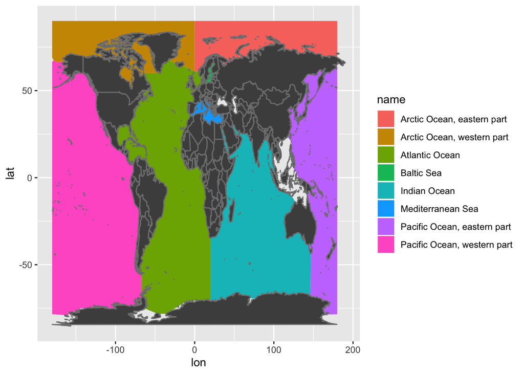

# Overview

The world ocean is 362,033,000 km2 (Menard & Smith, 1966 in Jakobsson et al., 2002). According to Jakobsson et al. (2002) the Arctic Ocean, as defined by the International Hydrographic Organization (1953), is 15,551,000 km2 or about 4.3% of the global ocean.

In the present analysis, the Arctic Ocean is as defined by the International Hydrographic Organization (1953) using the following dataset:

International Hydrographic Organization, IHO; Sieger, Rainer (2012): Limits of oceans and seas in digitized, machine readable form. Alfred Wegener Institute, Helmholtz Centre for Polar and Marine Research, Bremerhaven, PANGAEA, https://doi.org/10.1594/PANGAEA.777975

Calculation of the surface area of the Arctic Ocean using GMT (script below) was finally not used:

- north of 60°N: 1.6751e+07 km2, or 4.6% of the global ocean.
- north of 75°N: 7.11213e+06 km2, or 2% of the global ocean.

# SOCAT Product

```
##            Arctic Ocean          Atlantic Ocean              Baltic Sea
##                 2116569                 4678113                 2876536
## East Indian Archipelago            Indian Ocean       Mediterranean Sea
##                     116                  423878                  125922
##                   Other           Pacific Ocean          Southern Ocean
##                    5479                 4424875                 2484582
```

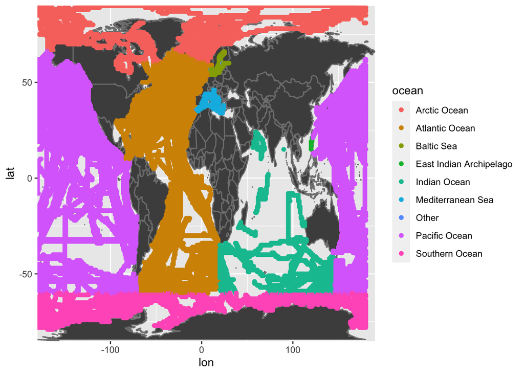

[figure not shown]

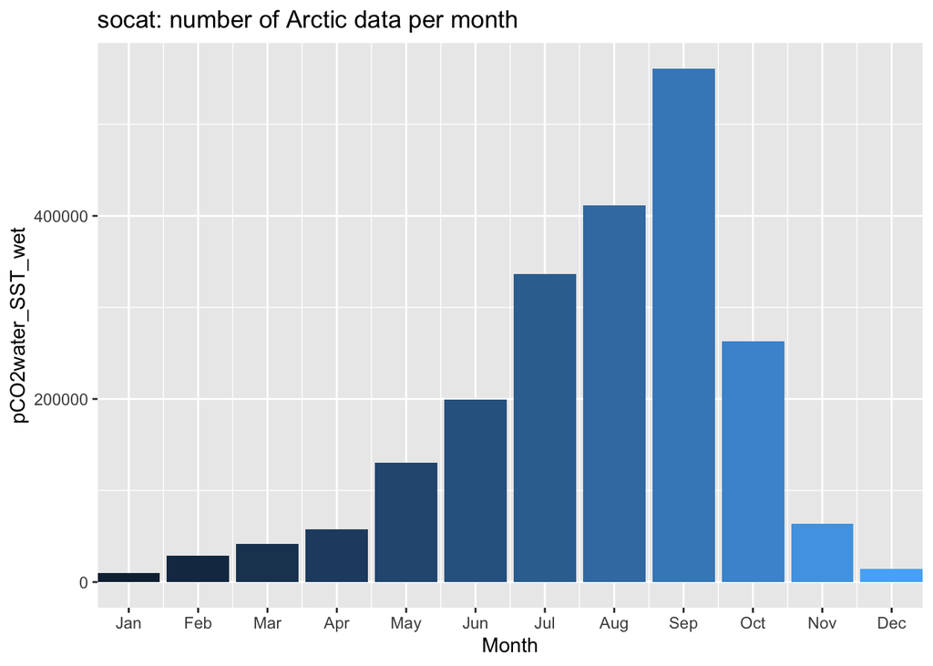

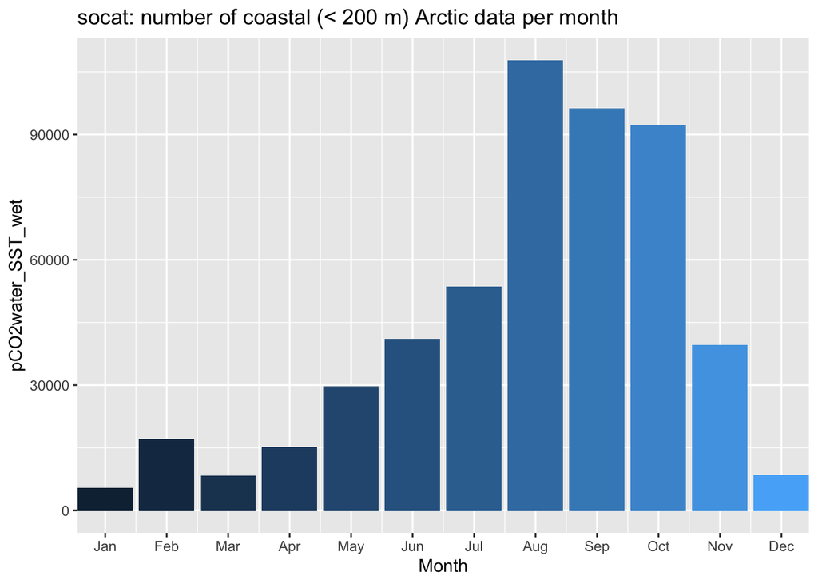

SOCAT v2022 has 17136070 records of pCO2water_SST_wet [uatm], including:

- 2116569 in the Arctic Ocean, or 12.4% of the global number of records
- 514562 in the Arctic Ocean shelf waters (shallower than 200 m), or 24.3% of the number of records in the Arctic.
- 71.2% of all Arctic data have been collected over 4 months (June to September).
- 58% of the shelf (< 200m) data have been collected over 4 months (June to September).

# GLODAP product

```
##            Arctic Ocean          Atlantic Ocean East Indian Archipelago
##                  153575                  453463                    3372
##            Indian Ocean       Mediterranean Sea           Pacific Ocean
##                  129894                    2626                  534760
##          Southern Ocean
##                  102279
```

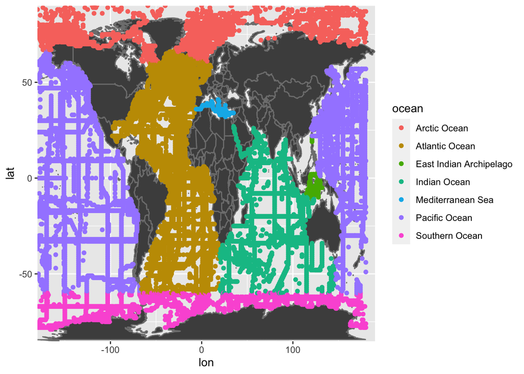

```
## # A tibble: 43 × 2
##     year     n
##    <dbl> <int>
##  1  1972   368
##  2  1974    29
##  3  1980  1072
##  4  1981   923
##  5  1982  2599
##  6  1984   762
##  7  1985    34
##  8  1986   247
##  9  1987  1228
## 10  1988    53
## # … with 33 more rows
```

[figure not shown]

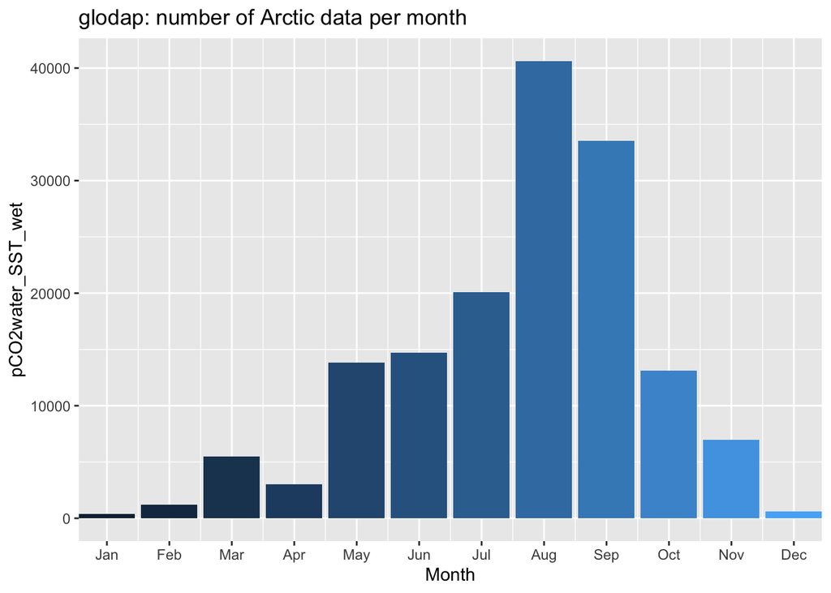

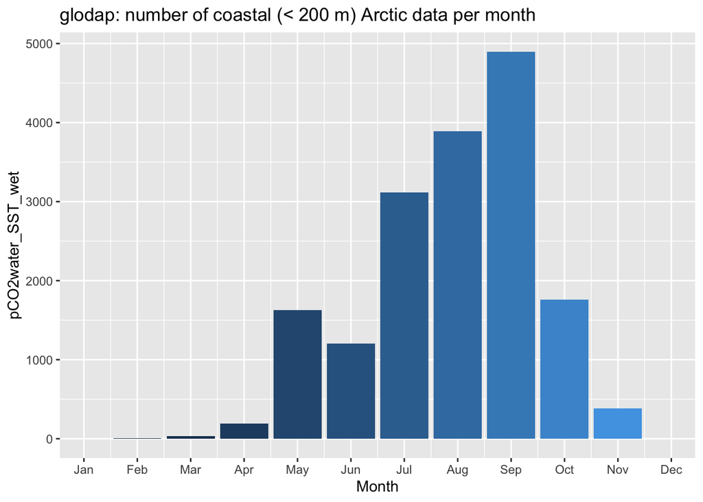

GLODAP v2.2022 has 1379969 records of TCO2, including:

- 153575 in the Arctic Ocean, or 11.1% of the total number of records
- 17105 in the Arctic Ocean shelf waters (shallower than 200 m) or 11.1% of the total number of records in the Arctic
- 71% of all Arctic data have been collected over 4 months (June to September).
- 76.8% of the shelf (< 200m) data have been collected over 4 months (June to September).

# Comparison

With the Arctic region investigated for both products we now want to compare them for the Arctic, Atlantic, Indian, Pacific, and Southern oceans. For both the full oceans as well as coastal (<= 200 m bottom depth) values. To do so we will use the bottom depths accompanied by the products.

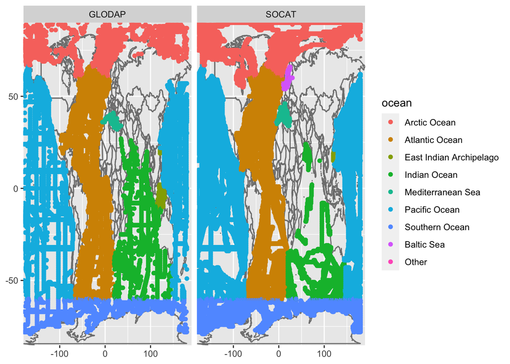

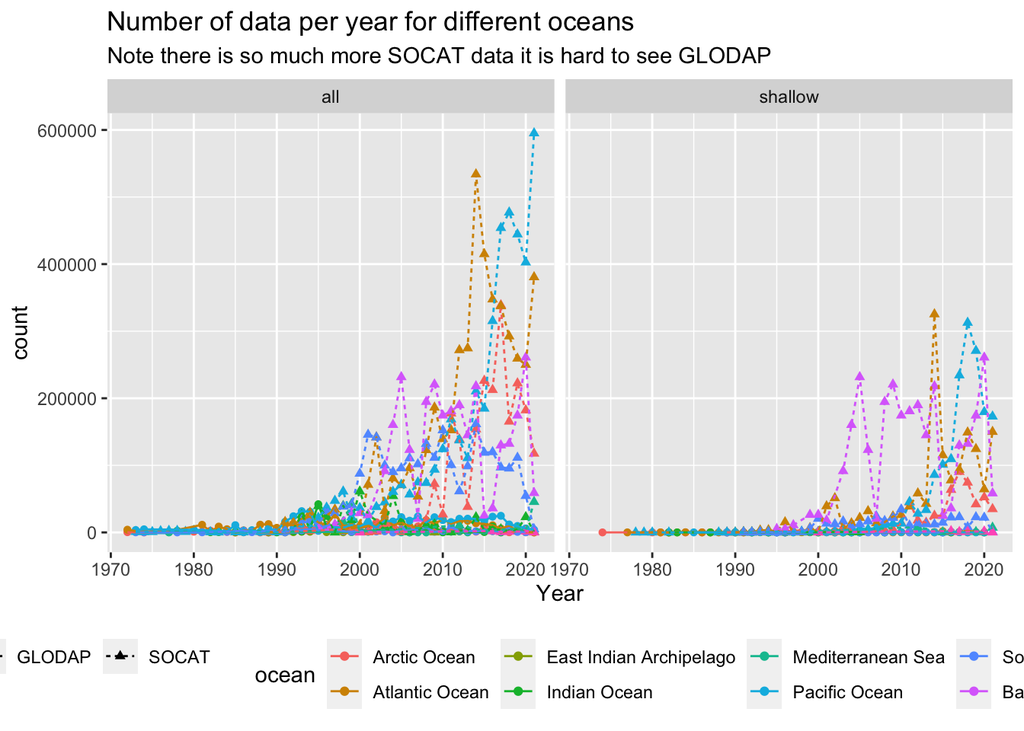

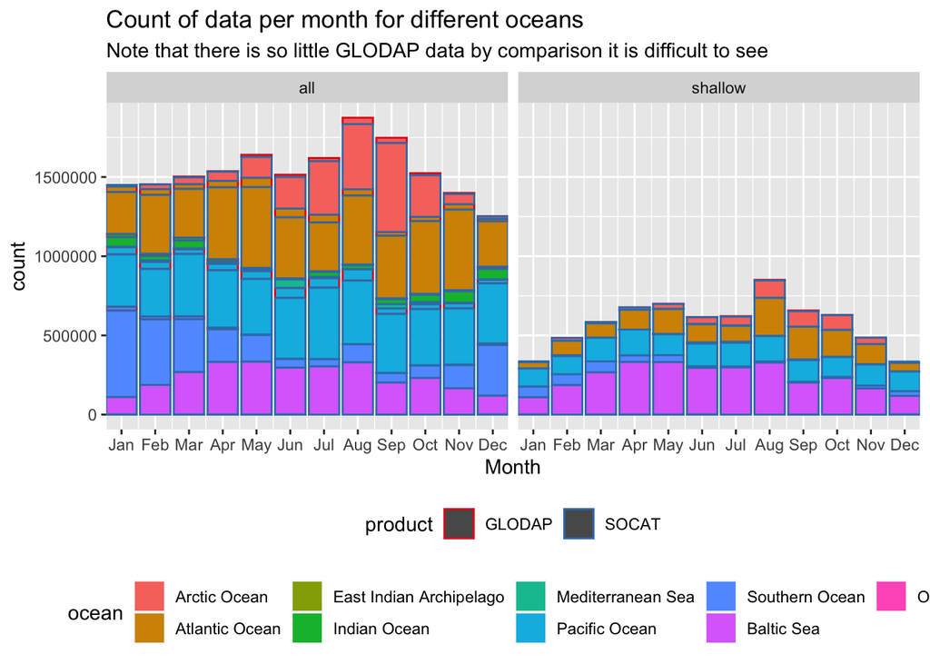

# Appendix: GMT script

Works but results not used in the manuscript in the end.

```
——
bash
cd
cd "pCloud Drive/FACE-IT_data/maps/GEBCO/"

# masque terre
gmt grdlandmask -Gnewmask.nc -RGEBCO_2020.nc -Df -N1/NaN/NaN/NaN/NaN

# selection de l ocean a partir du masques
gmt grdmath GEBCO_2020.nc newmask.nc OR = wet0.nc
# il reste des valeurs positives que j'élimine
gmt grdclip wet0.nc -Gwet.nc -Sa0/NaN

# calcul de la surface de l ocean, latitude > 75 degrés
#  la valeur -10000 que j'ai donnée à l'option -C de grdvolume
#  est une profondeur (en valeur absolue supérieure à la profondeur maximale
#  de l'océan), ce qui permet, si j'ai bien compris le fonctionnement
#  de grdvolume) de prendre en compte toute la surface de l'océan
gmt grdvolume wet.nc -R-180/180/75/90 -C-10000 -Sk > grdv_wet_75

# calcul de la surface de l ocean, latitude > 60 degrés
gmt grdvolume wet.nc -R-180/180/60/90 -C-10000 -Sk > grdv_wet_60.txt

# la surface est la somme des surfaces des 2 demi-hémisphères
#   (la surface est la 2ième valeur sortie par grdvolume)
#   (l unité de surface est le km2)
cat grdv_wet_75_dh? | awk 'BEGIN{s=0};{s=s+$2};END{print s}'
# 7.11213e+06
# Moi je trouve 7112242
cat grdv_wet_60_dh? | awk 'BEGIN{s=0};{s=s+$2};END{print s}'
# 1.6751e+07
# Moi je trouve 16768436

# j ai calculé pour latitude > 60 afin de comparer avec la surface
#  de l océan arctique donnée par wikipédia : 1.4e+7 km2
```